# Markdown_Franco.Rmd

Diego Franco

2023-31-01

### 4.10

```
## [1] "Thomas Coven"
## [1] "Rebecca Sugar"
## [1] "Laurent Bouzereau"
## [1] "Kaku Arakawa"
## [1] "Christin Baker"
## [1] "Miguel Angel Zavala"
## [1] "Dave Bullock"  "Troy Adomitis" "Victor Cook"
## [1] "Samuel Leong"
## [1] "Won Myeong-jun"
## [1] "Selena Quintanilla"
## [1] "Haruo Sotozaki"
## [1] "Ulises Valencia"
## [1] "Kim Nam-joon"   "Jeon Jung-kook" "Kim Tae-hyung"  "Park Ji-min"
## [5] "Jung Ho-seok"   "Kim Seok-jin"   "Min Yoon-gi"
```

## 4.11

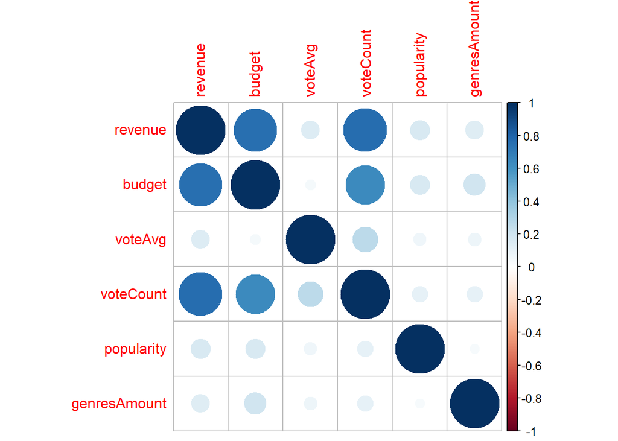

Por medio de la grafica nos podemos dar cuenta que existe una relacion entre el presupuesto y los ingresos de las peliculas. Cabe mencionar que existen datos a tipicos que no cumplen con la relacion pero esto no quiere decir que no exista.

## 4.12

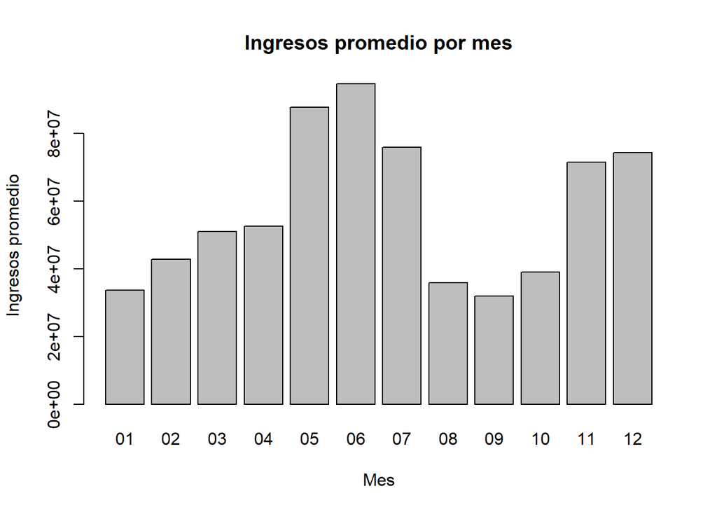

```r
meses <- as.Date(films[, c("releaseDate")])

ingresos_por_mes <- tapply(films$revenue, format(meses, "%m"), mean)

barplot(ingresos_por_mes, main="Ingresos promedio por mes", xlab="Mes", ylab="Ingresos promedio")
```

A partir de la grafica se puede asumir que los meses asociados con mejores ingresos son: mayo, junio, julio y diciembre.

## 4.13

Las peliculas con mejores ingresos se lanzaron en los siguinetes meses:

```
## [1] "noviembre" "diciembre" "abril"     "junio"     "julio"
```

En promedio por mes se lanzaron:

```
## [1] 12.8866
```

## 4.14

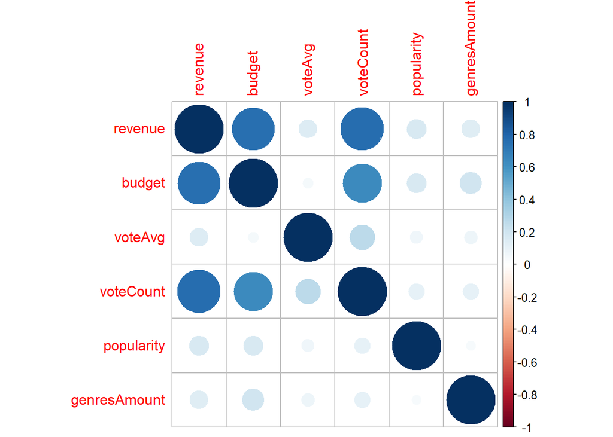

Como se observe en la grafica si existe una ralacion sobre las peliculas que obtuvieron mayor cantidad de ingresos con las que fueron mayor votadas.

## 4.15

Los generos principales de las peliculas mas largas son:

```
##  [1] "Action"          "Adventure"       "Drama"           "Crime"
##  [5] "Fantasy"         "Comedy"          "War"             "History"
##  [9] "Horror"          "Science Fiction" "Romance"         "Western"
## [13] "Family"          "Documentary"     "Thriller"        NA
## [17] "Music"
```

## ¿La popularidad de una película se relaciona con la popularidad de los actores en ella?

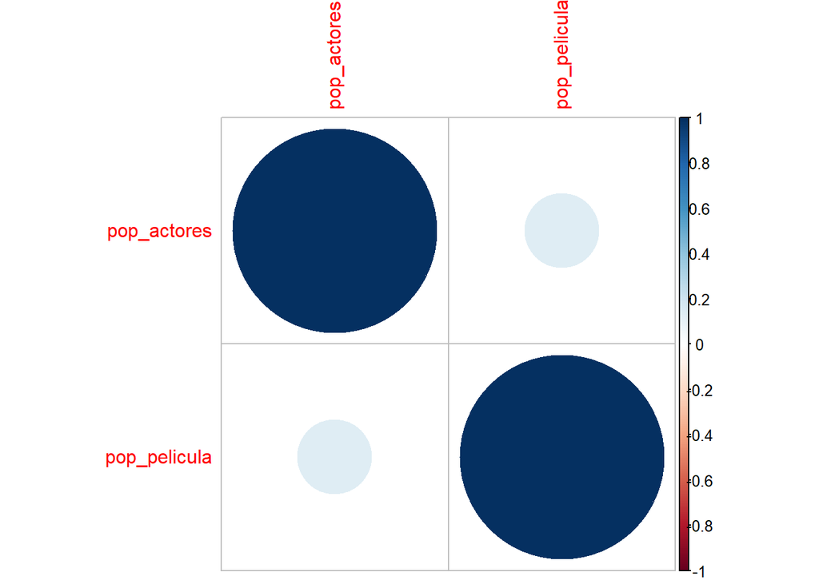

Tras observar el grafico se puede notar que la relacion entre la popularidad de las peliculas y la de los actores es muy pequeña y se puede considerar casi nula.

## ¿El presupuesto de una pelicula se relaciona con la popularidad de los actores en ella?

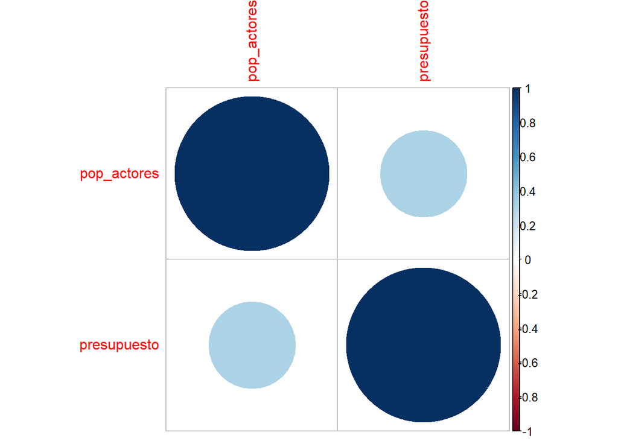

Como se puede observar en la grafica, puede existe una relacion entre el presupuesto de una pelicula y la popularidad de los actores.